### Report on Effects of Vitamin C on Tooth Growth in Guinea Pigs

#### Introduction

This is a course project for the Statistical Inference class. The goal of the project is to perform a basic inferential data analysis on the ToothGrowth data set in R. In this data set, the length of odontoblasts (teeth) were measured in each of 10 guinea pigs at each of three doses of Vitamin C (0.5, 1 and 2 mg) with each of two supplements (Orange Juice or Ascorbic Acid).

#### Preliminaries: Exploratory Data Analysis

The dataset is loaded and preliminary analysis is done to explore the behaviour of the data. First, we look at the structure of the data set:

```r
# Loading Data in R and doing preliminary check on dataset
data(ToothGrowth)
str(ToothGrowth)
```

```
## 'data.frame':    60 obs. of  3 variables:
##  $ len : num  4.2 11.5 7.3 5.8 6.4 10 11.2 11.2 5.2 7 ...
##  $ supp: Factor w/ 2 levels "OJ","VC": 2 2 2 2 2 2 2 2 2 2 ...
##  $ dose: num  0.5 0.5 0.5 0.5 0.5 0.5 0.5 0.5 0.5 0.5 ...
```

We can see that we have 60 observations and 3 variables: len (lenght of teeth), supp (type of supplement) and dose (amount of dosage). We notice that the variable dose is treated as numerical so we convert this to factor. Afterwhich, we look at the preliminary summary statistics:

```r
# Renaming dose and making it as factor and checking the summary statistics
ToothGrowth$dose = factor(ToothGrowth$dose, levels=c(0.5,1.0,2.0), labels=c("low","med","high"))
summary(ToothGrowth)
```

```
##       len        supp      dose
##  Min.   : 4.20   OJ:30   low :20
##  1st Qu.:13.07   VC:30   med :20
##  Median :19.25           high:20
##  Mean   :18.81
##  3rd Qu.:25.27
##  Max.   :33.90
```

Now that factors have been incorporated, we construct plots to visually inspect the behavior of the data and then generate some summary statistics of mean and sd to complement the graphs with numeric information.

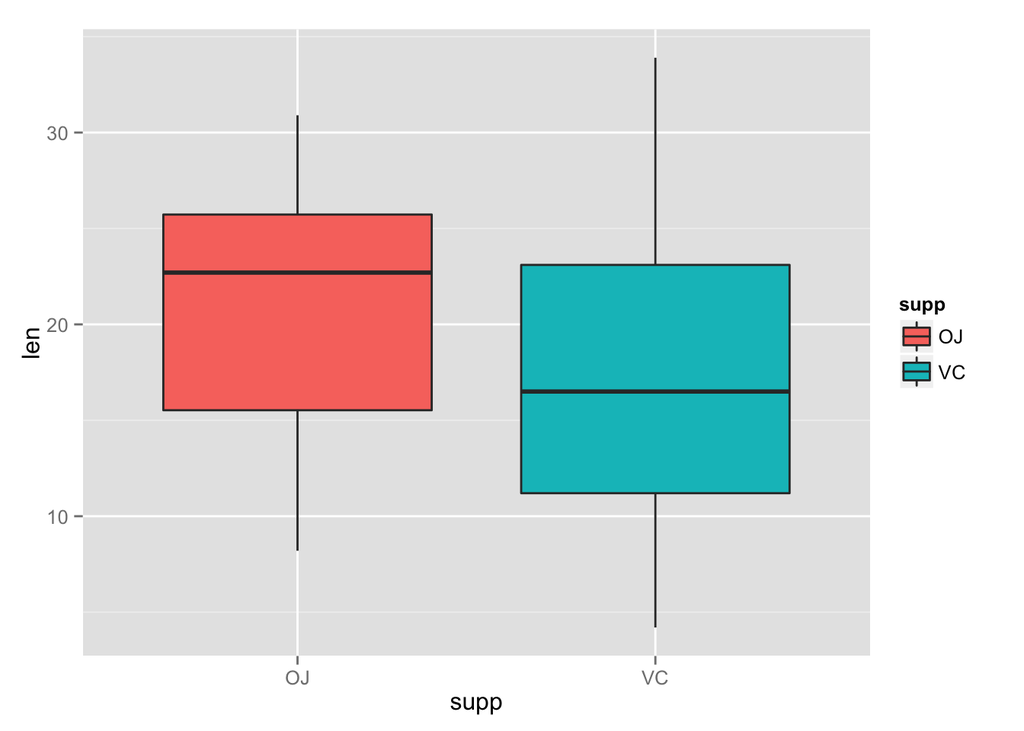

```
##   Group.1 x.mean  x.sd
## 1      OJ  20.66  6.61
## 2      VC  16.96  8.27
```

From this graph, it seems like those who received Orange Juice have a higher mean tooth length (20.66) than those who received Ascorbic Acid (16.96). There is also less variablity in those reeciving Orange Juice than Ascorbic Acid.

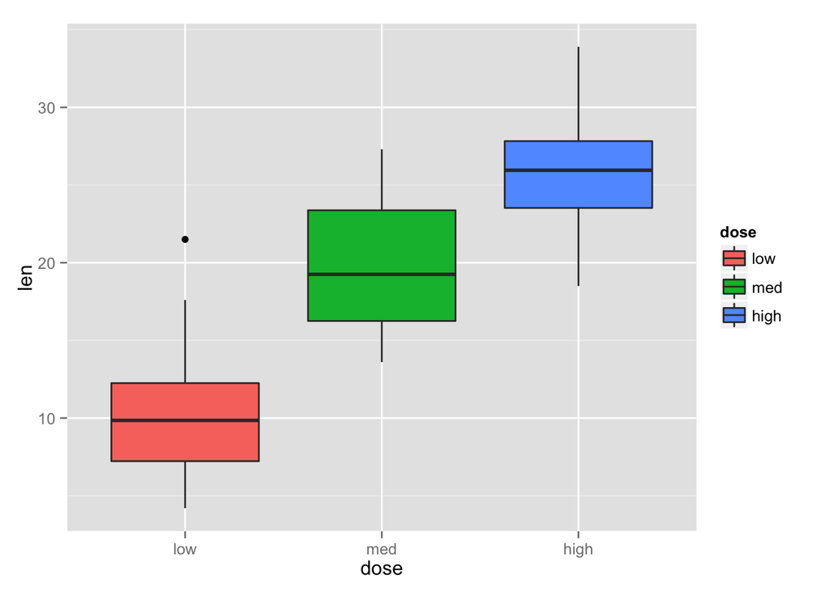

```
##   Group.1 x.mean  x.sd
## 1     low  10.61  4.50
## 2     med  19.73  4.42
## 3    high  26.10  3.77
```

This graph reveals that the higher the dose administered seems to have a higher effect on the mean tooth length.

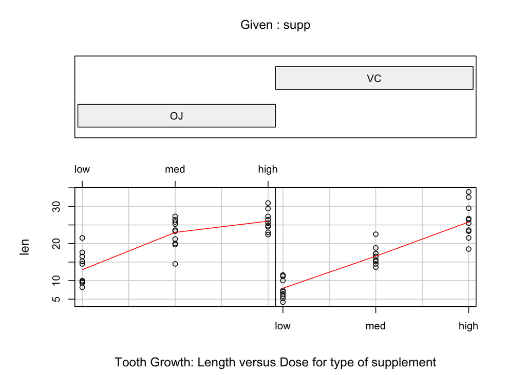

```
##   Group.1 Group.2 x.mean  x.sd
## 1      OJ     low  13.23  4.46
## 2      VC     low   7.98  2.75
## 3      OJ     med  22.70  3.91
## 4      VC     med  16.77  2.52
## 5      OJ    high  26.06  2.66
## 6      VC    high  26.14  4.80
```

The coplot suggests that administering Orange Juice in low and medium doses have higher mean length than those administered with Ascorbic Acid. For high dose though, it seems that the mean length for both type of supplements are the same.

Based on the observations we noted above, we want to answer the following questions:

1. Is the mean length for those administered with Orange Juice greater than those administered with Ascorbic Acid?
2. Is the mean length for those given low dose lesser than those given with medium/high dose? Is the mean length for those given medium dose lesser than those given with high dose?
3. Are the mean lengths of those given with Orange Juice at low and medium doses higher than those given with Ascorbic Acid? At high dose, are the mean length for both type of supplements the same?

To answer the questions, we now take a formal test and perform t-test to determine the difference in means of the length based on the factors.

#### T-test for Mean Difference by Type of Supplement

To determine whether the mean tooth length for those given with Orange Juice is higher than those given with ascorbic, we test: $H_0: \mu_{OJ} = \mu_{VC}$ versus $H_a: \mu_{OJ} > \mu_{VC}$.

```
##
##  Welch Two Sample t-test
##
## data:  len by supp
## t = 1.9153, df = 55.309, p-value = 0.03032
## alternative hypothesis: true difference in means is greater than 0
## 95 percent confidence interval:
##  0.4682687       Inf
## sample estimates:
## mean in group OJ mean in group VC
##         20.66333         16.96333
```

The results above show that at 5% level of significance, there is statistical significant difference between the mean length of those given Orange Juice (20.66) than Ascorbic Acid (16.96) with t = 1.91 and since p-value (0.03) is less than 0.05, we reject the null hypothesis.

#### T-test for Mean Difference by Level of Dose

To examine the mean tooth length by dose, we subset the data into smaller sets according to the combination of dosage sets.

```r
# Splitting the data for dosage pairs
dLowMed <- subset(ToothGrowth, dose %in% c("low", "med"))
dLowHigh <- subset(ToothGrowth, dose %in% c("low", "high"))
dMedHigh <- subset(ToothGrowth, dose %in% c("med", "high"))
```

We then perform t-test on the following:

1. $H_0: \mu_{low} = \mu_{med}$ versus $H_a: \mu_{low} < \mu_{med}$.

```
##
##  Welch Two Sample t-test
##
## data:  len by dose
## t = -6.4766, df = 37.986, p-value = 6.342e-08
## alternative hypothesis: true difference in means is less than 0
## 95 percent confidence interval:
##       -Inf -6.753323
## sample estimates:
## mean in group low mean in group med
##            10.605            19.735
```

2. $H_0: \mu_{low} = \mu_{high}$ versus $H_a: \mu_{low} < \mu_{high}$.

```
##
##  Welch Two Sample t-test
##
## data:  len by dose
## t = -11.799, df = 36.883, p-value = 2.199e-14
## alternative hypothesis: true difference in means is less than 0
## 95 percent confidence interval:
##       -Inf -13.27926
## sample estimates:
##  mean in group low mean in group high
##             10.605             26.100
```

3. $H_0: \mu_{med} = \mu_{high}$ versus $H_a: \mu_{med} < \mu_{high}$.

```
##
##  Welch Two Sample t-test
##
## data:  len by dose
## t = -4.9005, df = 37.101, p-value = 9.532e-06
## alternative hypothesis: true difference in means is less than 0
## 95 percent confidence interval:
##      -Inf -4.17387
## sample estimates:
##  mean in group med mean in group high
##             19.735             26.100
```

All the results above indicate that at 5% level of significance, the mean tooth length are all significantly different for each of the dosage pairs (low vs med, low vs high and med vs high). With all three p-values being very small, we reject all null hypotheses that the mean differences by dose are equal to 0.

#### T-test for Mean Difference of Type of Supplement by Level of Dose

To test the mean differnce of the type of suplement for each dosage type, we first subset the data by level of dose.

```r
#Splitting the data by dose
dLow <- subset(ToothGrowth, dose == "low")
dMed <- subset(ToothGrowth, dose == "med")
dHigh <- subset(ToothGrowth, dose == "high")
```

Then we coduct the t-test on the following:

1. $H_0: \mu_{OJ|low} = \mu_{VC|low}$ versus $H_a: \mu_{OJ|low} > \mu_{VC|low}$.

```
##
##  Welch Two Sample t-test
##
## data:  len by supp
## t = 3.1697, df = 14.969, p-value = 0.003179
## alternative hypothesis: true difference in means is greater than 0
## 95 percent confidence interval:
##  2.34604     Inf
## sample estimates:
## mean in group OJ mean in group VC
##            13.23             7.98
```

2. $H_0: \mu_{OJ | med} = \mu_{VC|med}$ versus $H_a: \mu_{OJ|med} > \mu_{VC|med}$.

```
##
##  Welch Two Sample t-test
##
## data:  len by supp
## t = 4.0328, df = 15.358, p-value = 0.0005192
## alternative hypothesis: true difference in means is greater than 0
## 95 percent confidence interval:
##  3.356158      Inf
## sample estimates:
## mean in group OJ mean in group VC
##            22.70            16.77
```

3. $H_0: \mu_{OJ | high} = \mu_{VC|high}$ versus $H_a: \mu_{OJ|high} <> \mu_{VC|high}$.

```
##
##  Welch Two Sample t-test
##
## data:  len by supp
## t = -0.0461, df = 14.04, p-value = 0.9639
## alternative hypothesis: true difference in means is not equal to 0
## 95 percent confidence interval:
##  -3.79807  3.63807
## sample estimates:
## mean in group OJ mean in group VC
##            26.06            26.14
```

Looking at the t-statistics. p-value and confidence intervals generate from the tests above, we can say see that at 5% level of significance, the first two tests involving low and medium doses have statistical differences in the mean length for those given with Orange Juice and Ascorbic Acid. With very small p-values, we reject the null hypothesis. However, for the test involving high dose, with t = -0.05 and p-value at 0.96, we do not reject the null hypothesis. Moreover, the confidence interval contains 0, further telling that there is no difference in the mean length between both sypplement type for this dose level.

#### Conclusions

Results of the t-tests done for this project leads us to the following conclusions:

1.) Rejecting the null hypothesis in testing the mean difference by type of supplement suggests that those given with Orange Juice tend to have higher mean tooth length than those given with Ascorbic Acid, unaccounting for other factors.

2.) Rejecting all null hypotheses in testing the mean difference by dose suggests that the higher the dose given, the higher the mean length of tooth in guinea pigs will be.

3.) Rejecting the null hypothesis in testing the mean difference for type of supplement in the low and medium doses suggest that in giving 0.5 mg and 1 mg doses of vitamins, Orange Juice have a higher effect on the mean tooth length than Ascorbic Acid. However, when giving 2mg dose, Orange Juice and Ascorbic Acid have the same effect on the mean tooth length.

#### Assumptions

We assume that the dosage and type of supplement were randomily given to the 60 test animals and that the sample are representative of the population of guinea pigs. We also assumed that the variances between the groups being tested are not equal.